# Practical Machine Learning Course Project

Radu Craioveanu

August 18, 2015

# Background

Using devices such as Jawbone Up, Nike FuelBand, and Fitbit it is now possible to collect a large amount of data about personal activity relatively inexpensively. These type of devices are part of the quantified self movement – a group of enthusiasts who take measurements about themselves regularly to improve their health, to find patterns in their behavior, or because they are tech geeks. One thing that people regularly do is quantify how much of a particular activity they do, but they rarely quantify how well they do it. In this project, the goal will be to use data from accelerometers on the belt, forearm, arm, and dumbell of 6 participants. They were asked to perform barbell lifts correctly and incorrectly in 5 different ways. More information is available from the website here: http://groupware.les.inf.puc-rio.br/har (see the section on the Weight Lifting Exercise Dataset).

# Data

The training data for this project are available here:

https://d396qusza40orc.cloudfront.net/predmachlearn/pml-training.csv

The test data are available here:

https://d396qusza40orc.cloudfront.net/predmachlearn/pml-testing.csv

The data for this project come from this source: http://groupware.les.inf.puc-rio.br/har.

# Project Goals

The goal of this project is to predict the manner in which they did the exercise. This is the “classe” variable in the training set. The Report will be describing how the model was built, how cross validation was used, what the expected out of sample error is, and why various choices were made. The prediction model will also be used to predict 20 different test cases.

The classe variable has the following categories to determine how an exercise is performed.

Class A: exactly according to the specification Class B: throwing the elbows to the front Class C: lifting the dumbbell only halfway Class D: lowering the dumbbell only halfway Class E: throwing the hips to the front

# Getting and Cleaning Data

## Setup Environment

```r
library(caret)
library(rpart)
library(rpart.plot)
library(randomForest)
library(knitr)
```

## Download and Read Data

Download the data fiels and read them into data frames to be used in the project

```r
trainUrl <-"https://d396qusza40orc.cloudfront.net/predmachlearn/pml-training.csv"
testUrl <- "https://d396qusza40orc.cloudfront.net/predmachlearn/pml-testing.csv"
trainFile <- "./data/pml-training.csv"
testFile  <- "./data/pml-testing.csv"
if (!file.exists("./data")) {
  dir.create("./data")
}
if (!file.exists(trainFile)) {
  download.file(trainUrl, destfile=trainFile, method="curl")
}
if (!file.exists(testFile)) {
  download.file(testUrl, destfile=testFile, method="curl")
}
#read the files into the respective data frames
trainRaw <- read.csv("./data/pml-training.csv")
testRaw <- read.csv("./data/pml-testing.csv")
#check the number observations and features of each data set
cat("Raw Train Observations =", dim(trainRaw)[1], "with Features = ", dim(trainRaw)[2])
```

```
## Raw Train Observations = 19622 with Features =  160
```

```r
cat("Raw Test Observations =", dim(testRaw)[1], "with Features = ", dim(testRaw)[2])
```

```
## Raw Test Observations = 20 with Features =  160
```

## Clean Data

Remove NA values, unnecessary columns, and allow for a smaller sample size to get an optimal algorithm.

```r
#filter our the missing values (NA) in both sets
trainRaw <- trainRaw[, colSums(is.na(trainRaw)) == 0]
testRaw <- testRaw[, colSums(is.na(testRaw)) == 0]

#save classe before we clean up trainRaw
classe <- trainRaw$classe
#get rid of some columns that have no value
trainRemove <- grepl("^X|timestamp|window", names(trainRaw))
trainRaw <- trainRaw[, !trainRemove]
trainClean <- trainRaw[, sapply(trainRaw, is.numeric)]
trainClean$classe <- classe
#repeat for the test set
testRemove <- grepl("^X|timestamp|window", names(testRaw))
testRaw <- testRaw[, !testRemove]
testClean <- testRaw[, sapply(testRaw, is.numeric)]

#new set dimenstions
cat("Clean Train Observations =", dim(trainClean)[1], "with Features = ", dim(trainClean)[2])
```

```
## Clean Train Observations = 19622 with Features =  53
```

```r
cat("Clean Test Observations =", dim(testClean)[1], "with Features = ", dim(testClean)[2])
```

```
## Clean Test Observations = 20 with Features =  53
```

```r
#slim down the data set, in particular the training set, as the algorithms may take too long, also set some data aside for validation
set.seed(9595)
trainIndex <- createDataPartition(y = trainClean$classe,p=0.8,list=FALSE)
trainClean <- trainClean[trainIndex,]
cat("Clean Train Observations =", dim(trainClean)[1], "with Features = ", dim(trainClean)[2])
```

```
## Clean Train Observations = 15699 with Features =  53
```

```r
#create a train and a validation set with a 70% and 30% content respectively
set.seed(7676)
trainCleanIndex <- createDataPartition(y = trainClean$classe,p=0.7,list=FALSE)
trainSet <- trainClean[trainCleanIndex,]
validSet <- trainClean[-trainCleanIndex,]

#new set
cat("Set Train Observations =", dim(trainSet)[1], "with Features = ", dim(trainSet)[2])
```

```
## Set Train Observations = 10992 with Features =  53
```

```r
cat("Set Validation Observations =", dim(validSet)[1], "with Features = ", dim(validSet)[2])
```

```
## Set Validation Observations = 4707 with Features =  53
```

# Modeling

There were many options available here, but the main decision was driven by some of the performance requirements as well as the number we were able to get on the Accuracy and Sampling Error. I chose the Random Forest algorithm from the randomForest library as opposed to the one from the caret library, as the latter took very long due to the thousands of trees it created.

Run the model

```r
#the caret package took too long
#controlRf <- trainControl(method = "cv", 10)
#modelRf <- train(classe ~., data=trainSet, method = "rf", trControl = controlRf,
#                 prox = TRUE, allowParallel = TRUE)

#the rendomForest library train worked much better
modelRf = randomForest(classe ~.,data = trainSet, importance=TRUE, proximity = TRUE)
modelRf
```

```
##
## Call:
##  randomForest(formula = classe ~ ., data = trainSet, importance = TRUE,      proximity = TRUE)
##                Type of random forest: classification
##                      Number of trees: 500
## No. of variables tried at each split: 7
##
##         OOB estimate of  error rate: 0.73%
## Confusion matrix:
##      A    B    C    D    E class.error
## A 3117    5    2    0    1 0.002560000
## B   12 2107    8    0    0 0.009402915
## C    0   11 1903    3    0 0.007303078
## D    1    0   24 1773    4 0.016093230
## E    0    0    2    7 2012 0.004453241
```

Perform the validation and check the accuracy

```r
predictRf <- predict(modelRf,validSet)
cMat <- confusionMatrix(validSet$classe, predictRf)
#accuracy <- postResample(predictRf,testSet$classe)
outOfSampleError <- 1 - as.numeric(confusionMatrix(validSet$classe, predictRf)$overall[1])
accuracy <- cMat$overall[1]
cat("Estimated accuracy: ", accuracy, "with OOS Error: ",outOfSampleError)
```

```
## Estimated accuracy:  0.9921394 with OOS Error:  0.007860633
```

# Predicting

```r
#remove the problem_id column
testClean <- testClean[,-length(names(testClean))]
result <- predict(modelRf, testClean)
result
```

```
##  1  2  3  4  5  6  7  8  9 10 11 12 13 14 15 16 17 18 19 20
##  B  A  B  A  A  E  D  B  A  A  B  C  B  A  E  E  A  B  B  B
## Levels: A B C D E
```

# Appendix

## Tree visualization

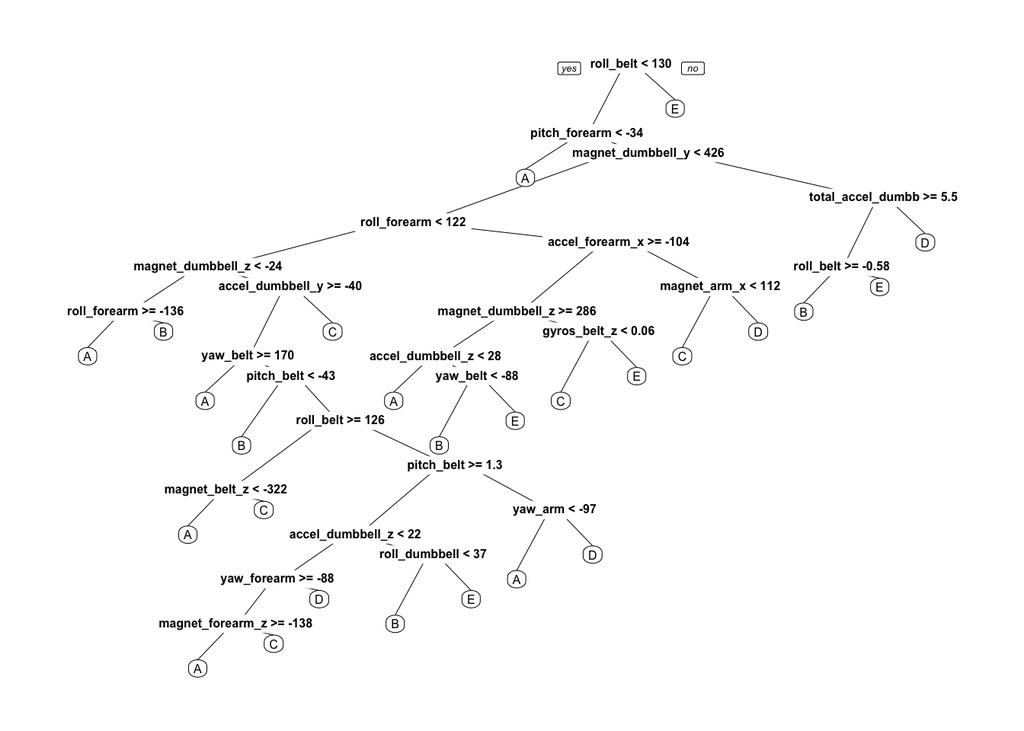

```r
treeModel <- rpart(classe ~., data=trainSet, method = "class")
prp(treeModel)
```